# Between sample/beta diversity of Microbes by gut section

# Calculate & Visualize Community Dissimiliarity

Exploratory analyses from the Paily & Shankar (2016) paper, which is using unconstrained ordination methods like PCoA.

## Sorenson PCoA

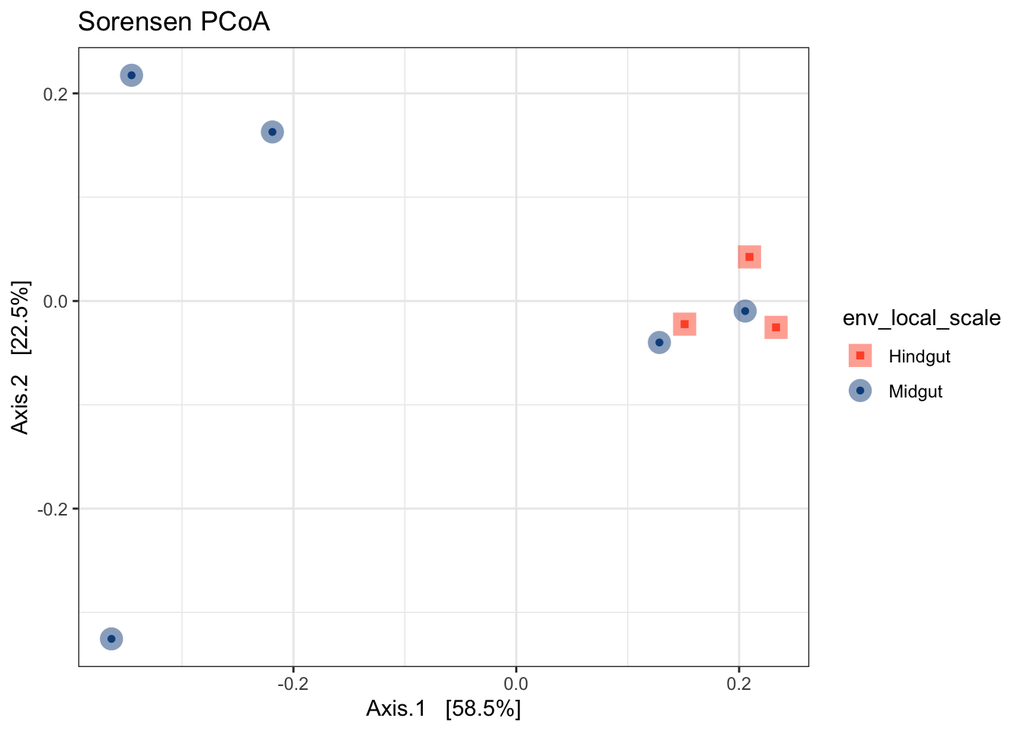

```r
# Calculate sorenson dissimularity: Abundance-unweighted of shared taxa
scaled_soren_pcoa <-
  ordinate(
    physeq = scaled_rooted_physeq,
    method = "PCoA",
    distance = "bray", binary = TRUE)

#str(scaled_soren_pcoa)

# Plot the ordination
soren_gut_section_pcoa <- plot_ordination(
  physeq = scaled_rooted_physeq,
  ordination = scaled_soren_pcoa,
  color = "env_local_scale",
  shape = "env_local_scale",
  title = "Sorensen PCoA") +
  geom_point(size=5, alpha = 0.5, aes(color = env_local_scale)) +
  scale_shape_manual(values = c(15,16)) +
  scale_color_manual(values = gut_section_colors) +
  theme_bw()
# Show the plot
soren_gut_section_pcoa
```

Here, we are evaluating the shared taxa by presence/absence (abundance-unweighted) in the Sorensen metric.

Note that:

- Axis 1 = ~58.5% of variation
- Axis 2 = ~22.5% of variation

## Bray-Curtis PCoA

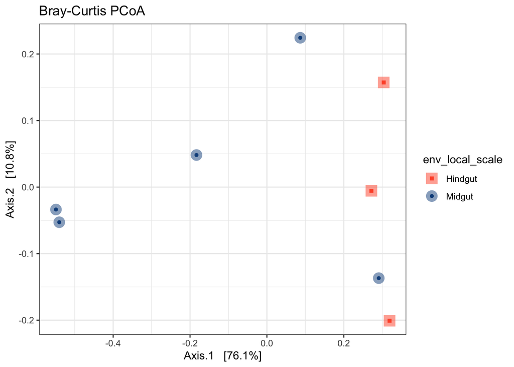

```r
# Calculate the BC distance
scaled_BC_pcoa <-
  ordinate(
    physeq = scaled_rooted_physeq,
    method = "PCoA",
    distance = "bray")

# Plot the PCoA
bray_gut_section_pcoa <-
  plot_ordination(
    physeq = scaled_rooted_physeq,
    ordination = scaled_BC_pcoa,
    color = "env_local_scale",
    shape = "env_local_scale",
    title = "Bray-Curtis PCoA") +
  geom_point(size=5, alpha = 0.5, aes(color = env_local_scale)) +
  scale_shape_manual(values = c(15,16)) +
  scale_color_manual(values = c(gut_section_colors)) +
  theme_bw()
bray_gut_section_pcoa
```

Here, we are evaluating the shared taxa and then weighting them by their abundances, which provides more influence for species that are more abundant.

Note that:

- Axis 1 = ~76.1% of variation
- Axis 2 = ~10.8% of variation

## Weighted-Unifrac PCoA

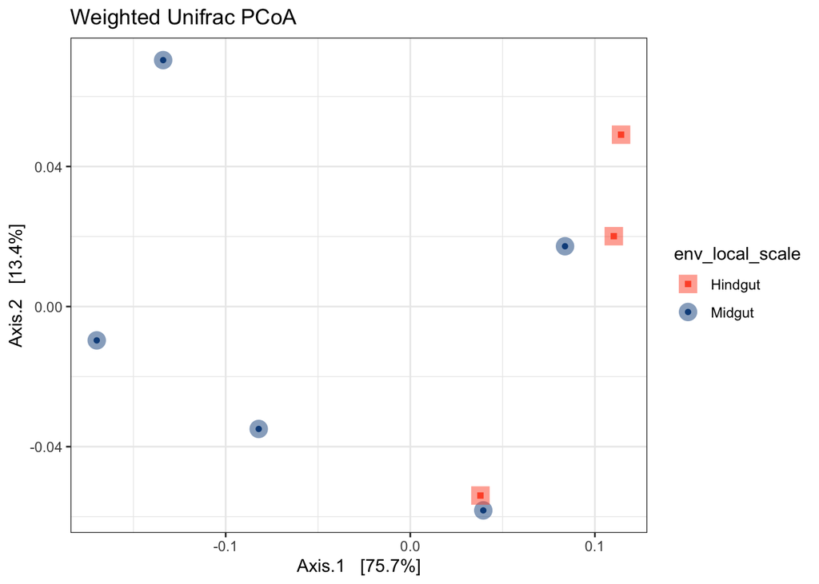

```r
# Calculate the BC distance
scaled_wUNI_pcoa <-
  ordinate(
    physeq = scaled_rooted_physeq,
    method = "PCoA",
    distance = "wunifrac")

# Plot the PCoA
wUNI_gut_section_pcoa <-
  plot_ordination(
    physeq = scaled_rooted_physeq,
    ordination = scaled_wUNI_pcoa,
    color = "env_local_scale",
    shape = "env_local_scale",
    title = "Weighted Unifrac PCoA") +
  geom_point(size=5, alpha = 0.5, aes(color = env_local_scale)) +
  scale_shape_manual(values = c(15,16)) +
  scale_color_manual(values = c(gut_section_colors)) +
  theme_bw()
wUNI_gut_section_pcoa
```

Here, we are evaluating the shared taxa and then weighting them by their abundances, which provides more influence for species that are more abundant.

Note that:

- Axis 1 = ~75.7% of variation
- Axis 2 = ~13.4% of variation

## Combine PCoAs

Let’s plot all three together into one plot to have a concise visualization of the three metrics.

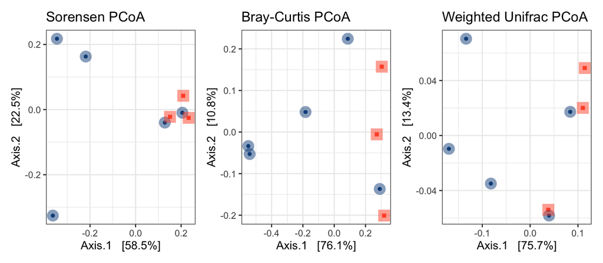

```r
(soren_gut_section_pcoa + theme(legend.position = "none")) +
  (bray_gut_section_pcoa + theme(legend.position = "none")) +
    (wUNI_gut_section_pcoa + theme(legend.position = "none"))
```

## NMDS

```r
# Calculate the Weighted Unifrac distance
scaled_wUNI_nmds <-
  ordinate(
    physeq = scaled_rooted_physeq,
    method = "NMDS",
    distance = "bray")
```

```
## Square root transformation
## Wisconsin double standardization
## *** Best solution repeated 2 times
```

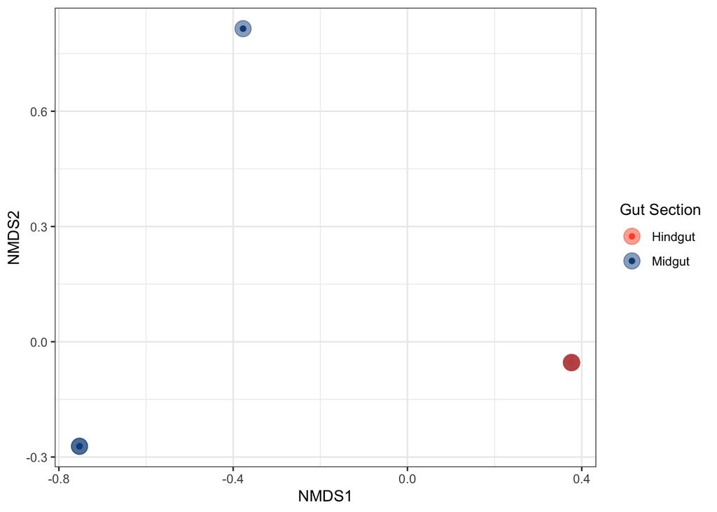

```r
# Plot the PCoA
wUNI_gut_section_nmds <-
  plot_ordination(
    physeq = scaled_rooted_physeq,
    ordination = scaled_wUNI_nmds,
    color = "env_local_scale") +
  geom_point(size=5, alpha = 0.5, aes(color = env_local_scale)) +
  scale_shape_manual(values = c(15,16)) +
  scale_color_manual(values = c(gut_section_colors)) +
  theme_bw() + labs(color = "Gut Section")
wUNI_gut_section_nmds
```

In this case, I would always prefer to report the PCoA results because they are linear and provide a lot more post-hoc analyses to follow up with. In addition, it’s helpful to only have 2 axes of variation and show how much variation is explained.

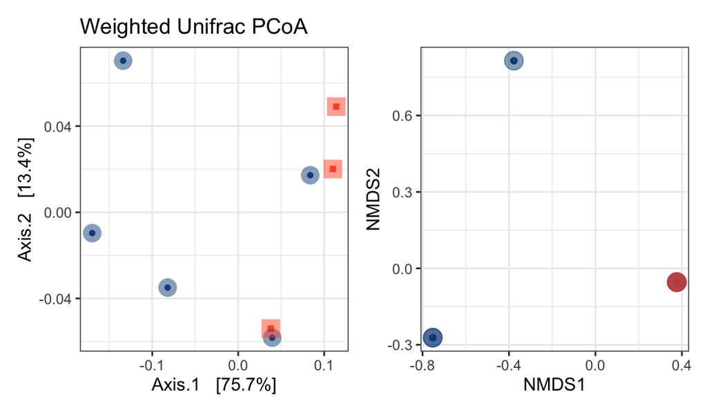

```r
(wUNI_gut_section_pcoa + theme(legend.position = "none")) +
  (wUNI_gut_section_nmds + theme(legend.position = "none"))
```

# Statistical Significance Testing

## PERMANOVA

```r
# Calculate all three of the distance matrices
scaled_sorensen_dist <- phyloseq::distance(scaled_rooted_physeq,
                                           method = "bray", binary = TRUE)
scaled_bray_dist <- phyloseq::distance(scaled_rooted_physeq, method = "bray")
scaled_wUnifrac_dist <- phyloseq::distance(scaled_rooted_physeq,
                                           method = "wunifrac")

# make a data frame from the sample_data
# All distance matrices will be the same metadata because they
# originate from the same phyloseq object.
metadata <- data.frame(sample_data(scaled_rooted_physeq))

# Adonis test
# In this example we are testing the hypothesis that the five stations
# that were collected have different centroids in the ordination space
# for each of the dissimilarity metrics, we are using a discrete variable
adonis2(scaled_sorensen_dist ~ env_local_scale, data = metadata)
```

```
## Permutation test for adonis under reduced model
## Permutation: free
## Number of permutations: 999
##
## adonis2(formula = scaled_sorensen_dist ~ env_local_scale, data = metadata)
##          Df SumOfSqs      R2      F Pr(>F)
## Model     1  0.19152 0.23416 1.8345  0.087 .
## Residual  6  0.62640 0.76584
## Total     7  0.81792 1.00000
## ---
## Signif. codes:  0 '***' 0.001 '**' 0.01 '*' 0.05 '.' 0.1 ' ' 1
```

```r
adonis2(scaled_bray_dist ~ env_local_scale, data = metadata)
```

```
## Permutation test for adonis under reduced model
## Permutation: free
## Number of permutations: 999
##
## adonis2(formula = scaled_bray_dist ~ env_local_scale, data = metadata)
##          Df SumOfSqs     R2      F Pr(>F)
## Model     1  0.45047 0.3476 3.1968  0.106
## Residual  6  0.84547 0.6524
## Total     7  1.29594 1.0000
```

```r
adonis2(scaled_wUnifrac_dist ~ env_local_scale, data = metadata)
```

```
## Permutation test for adonis under reduced model
## Permutation: free
## Number of permutations: 999
##
## adonis2(formula = scaled_wUnifrac_dist ~ env_local_scale, data = metadata)
##          Df SumOfSqs      R2      F Pr(>F)
## Model     1 0.038087 0.32475 2.8855  0.112
## Residual  6 0.079195 0.67525
## Total     7 0.117282 1.00000
```

Note that:

- R2 = the percent variation explained.
- F = the F-Statistic, which represents the importance value.
- Pr(>F) = the pvalue

```r
# # We might also care about other variables
# # Here, we will add date and fraction as variables
# # multiplicative model ORDER MATTERS!
# adonis2(scaled_sorensen_dist ~ gut_section * year, data = metadata)
# adonis2(scaled_bray_dist ~ gut_section * year, data = metadata)
# # Note that the ORDER MATTERS!
# adonis2(scaled_wUnifrac_dist ~ gut_section * year, data = metadata)
# adonis2(scaled_wUnifrac_dist ~ year * gut_section, data = metadata)
```

We can also run tests that include additive (+) or multipliciatve models, which include the interaction term between variables.

## BetaDispR

```r
# Homogeneity of Disperson test with beta dispr
# Sorensen
# beta_soren_gut_section <- betadisper(scaled_sorensen_dist, metadata$gut_section)
# permutest(beta_soren_gut_section)
#
# # Bray-curtis
# beta_bray_gut_section <- betadisper(scaled_bray_dist, metadata$gut_section)
# permutest(beta_bray_gut_section)
#
# # Weighted Unifrac
# beta_bray_gut_section <- betadisper(scaled_wUnifrac_dist, metadata$gut_section)
# permutest(beta_bray_gut_section)
```

# Taxonomic Composition

## Phylum

```r
# Set the phylum colors
phylum_colors <- c(
  Acidobacteriota = "navy",
  Actinobacteriota = "darkslategray2",
  Armatimonadota = "deeppink1",
  Alphaproteobacteria = "plum2",
  Bacteroidota = "gold",
  Betaproteobacteria = "plum1",
  Bdellovibrionota = "red1",
  Chloroflexi="black",
  Crenarchaeota = "firebrick",
  Cyanobacteria = "limegreen",
  Deltaproteobacteria = "grey",
  Desulfobacterota="magenta",
  Fibrobacterota = "darkgreen",
  Bacillota = "#3E9B96",
  Gammaproteobacteria = "greenyellow",
  "Marinimicrobia (SAR406 clade)" = "yellow",
  Myxococcota = "#B5D6AA",
  Nitrospirota = "palevioletred1",
  Pseudomonadota = "royalblue",
  Planctomycetota = "darkorange",
  Spirochaetota = "olivedrab",
  Thermoplasmatota = "green",
  Verrucomicrobiota = "darkorchid1")
```

#### Plot Phylum Composition

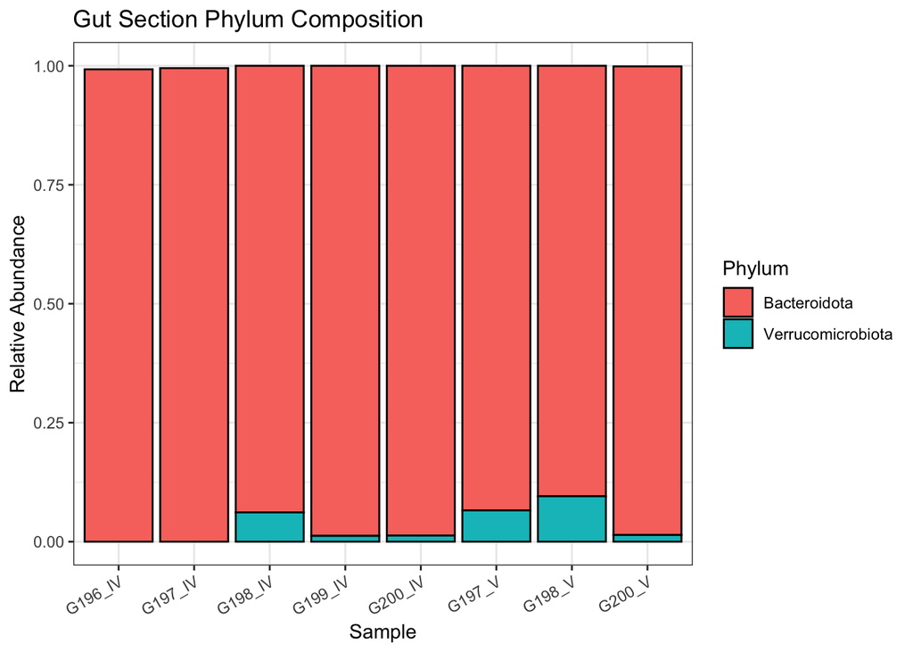

```r
# Goal is to calculate the phylum relative abundance
# Note: the read depth must be normalized in some way: scaled_reads
level_order <-
  c("G196_IV", "G197_IV", "G198_IV", "G199_IV", "G200_IV",
    "G197_V", "G198_V", "G200_V", "G201_V")

phylum_df <-
  scaled_rooted_physeq %>%
  # agglomerate at the phylum level
  tax_glom(taxrank = "Phylum") %>%
  # Transform counts to relative abundance
  transform_sample_counts(function (x) {x/sum(x)}) %>%
  # Melt to a long format
  psmelt() %>%
  # Filter out phyla that are less than one percent - get rid of low abundant Phyla
  dplyr::filter(Abundance > 0.01)
  # fix the order of date

# Stacked bar plot with all Phyla
# Plot Phylum Abundances - make sure to load phylum_colors
phylum_df %>%
  # Warning: Its important to have one sample per x value,
  # Otherwise, it will take the sum between multiple samples
  ggplot(aes(x = factor(Sample.Name, level = level_order),
 # ggplot(aes(x = Sample.Name,
             y = Abundance, fill = Phylum)) +
  #facet_grid(.~gut_section) +
  geom_bar(stat = "identity", color = "black") +
  labs(title = "Gut Section Phylum Composition", x= "Sample",
       y = "Relative Abundance") +
  #scale_fill_manual(values = phylum_colors) +
  theme_bw() +
  theme(axis.text.x = element_text(angle = 30, hjust = 1, vjust = 1))
```

[figure not shown]

```r
# Plot Phylum Abundances - make sure to load phylum_colors
phylum_df %>%
  # Warning: Its important to have one sample per x value,
  # Otherwise, it will take the sum between multiple samples
  ggplot(aes(x = factor(names, level = level_order),
             y = Abundance, fill = Phylum)) +
  geom_bar(stat = "identity", color = "black") +
  labs(title = "Gut Section Phylum Composition") +
  scale_fill_manual(values = phylum_colors) +
  theme_bw() +
  theme(axis.text.x = element_text(angle = 30, hjust = 1, vjust = 1)) +
  labs(y ="Relative Abundance",x = "Sample")
```

## Order

```r
# Set Order colors
# order_colors <- c(
#   Bacteroidales = "darkslategray2",
#   Christensenellales = "gold",
#   "Clostridia vadinBB60 group" = "deeppink1",
#   Clostridiales = "limegreen",
#   Cytophagales = "gray",
#   Desulfobacterales = "magenta4",
#   Desulfovibrionales = "black",
#   Enterobacterales = "firebrick",
#   Fibrobacterales = "yellow",
#   Gastranaerophilales = "greenyellow",
#   Lachnospirales = "yellow4",
#   Opitutales ="magenta",
#   Oscillospirales = "palevioletred1",
#   "P.palmC41"  = "orange3",
#   "Peptostreptococcales-Tissierellales" = "lightgreen",
#   Pseudomonadales = "purple2",
#   Spirochaetales = "royalblue",
#   Verrucomicrobiales  = "plum2",
#   Victivallales = "darkgray",
#   "WCHB1-41"=  "violetred"
# )
```

```r
# Order_df <-
#   scaled_rooted_physeq %>%
#   # agglomerate at the phylum level
#   tax_glom(taxrank = "Order") %>%
#   # Transform counts to relative abundance
#   transform_sample_counts(function (x) {x/sum(x)}) %>%
#   # Melt to a long format
#   psmelt() %>%
#   # Filter out phyla that are less than one percent - get rid of low abundant Phyla
#   dplyr::filter(Abundance > 0.01)
#
# #section_IV <-
# #  c('568_4','E1_4','E2_4','E3_4')
#
# #section_IV_df <- filter(Order_df, names == c('568_4','E1_4','E2_4','E3_4') )
#
# #section_V <-
# #  c('568_5', '581_5','611_5', 'E05_5', 'E1_5', 'E2_5', 'E3_5')
#
# #section_V_df <- filter(Order_df, names == section_V )
#
# #save(Order_df, file = "data/05_community_analysis/ASV_counts_order.RData")
#
# #write.csv2(Order_df, file = "data/05_community_analysis/ASV_counts_order.csv")
#
# #write.table(Order_df, "data/05_community_analysis/ASV_counts_order.tsv",
# #            sep = "\t", quote = FALSE, col.names = NA)
#
# # Facet by gut section
# Order_df %>%
#   # Warning: Its important to have one sample per x value,
#   # Otherwise, it will take the sum between multiple samples
#   ggplot(aes(x = names, y = Abundance, fill = Order)) +
#   facet_grid(.~gut_section) +
#   geom_bar(stat = "identity", color = "black") +
#   #scale_fill_manual(values = order_colors) +
#   theme_bw() +
#   theme(axis.text.x = element_text(angle = 30, hjust = 1, vjust = 1))
#
# level_order <-
#   c('568_4','E1_4','E2_4','E3_4','568_5', '581_5','611_5', 'E05_5', 'E1_5', 'E2_5', 'E3_5')
#
# Order_df %>%
#   # Warning: Its important to have one sample per x value,
#   # Otherwise, it will take the sum between multiple samples
#   ggplot(aes(x = factor(names, level = level_order),
#              y = Abundance, fill = Order)) +
#   #facet_grid(.~gut_section) +
#   geom_bar(stat = "identity", color = "black") +
#   scale_fill_manual(values = order_colors) +
#   theme_bw() +
#   theme(axis.text.x = element_text(angle = 30, hjust = 1, vjust = 1)) +
#   labs(y ="Relative Abundance",x = "Sample")
#
# # Section IV
#
# section_IV_df <- read.table("data/05_community_analysis/section_IV.tsv", sep = ",", skip = 1)
#
# head(section_IV_df)
#
# colnames(section_IV_df) <- c("", "OTU", "Sample", "Abundance", "names",
#                              "host_species", "gut_section", "region","loction", "year",
#                              "month", "day", "sample_lab", "Time", "SL.mm.", "FL.mm.",
#                              "TW..g.", "GW..g.", "Sex", "Sample_or_Control",
#                              "input", "filtered", "denoisedF", "denoisedR",
#                              "merged", "nochim", "perc_reads_retained", "Kingdom",
#                              "Phylum", "Class", "Order")
# head(section_IV_df)
#
# section_IV_df %>%
#   ggplot(aes(x = names,
#              y = Abundance, fill = Order)) +
#   geom_bar(stat = "identity", color = "black") +
#   scale_fill_manual(values = order_colors) +
#   theme_bw() +
#   theme(axis.text.x = element_text(angle = 30, hjust = 1, vjust = 1)) +
#   labs(y ="Relative Abundance",x = "Sample")
#
# # Section V
#
# section_V_df <- read.table("data/05_community_analysis/section_V.tsv", sep = ",", skip = 1)
#
# head(section_V_df)
#
# colnames(section_V_df) <- c("", "OTU", "Sample", "Abundance", "names",
#                              "host_species", "gut_section", "region","loction", "year",
#                              "month", "day", "sample_lab", "Time", "SL.mm.", "FL.mm.",
#                              "TW..g.", "GW..g.", "Sex", "Sample_or_Control",
#                              "input", "filtered", "denoisedF", "denoisedR",
#                              "merged", "nochim", "perc_reads_retained", "Kingdom",
#                              "Phylum", "Class", "Order")
# head(section_V_df)
#
# section_V_df %>%
#   ggplot(aes(x = names,
#              y = Abundance, fill = Order)) +
#   geom_bar(stat = "identity", color = "black") +
#   scale_fill_manual(values = order_colors) +
#   theme_bw() +
#   theme(axis.text.x = element_text(angle = 30, hjust = 1, vjust = 1)) +
#   labs(y ="Relative Abundance",x = "Sample")
```

## Genus

```r
# Set the phylum colors
Genus_colors <- c(
  Alistipes = "deeppink1",
  Gillisia = "gold",
  Lentimonas = "magenta4",
  Rikenella = "darkslategray2")
```

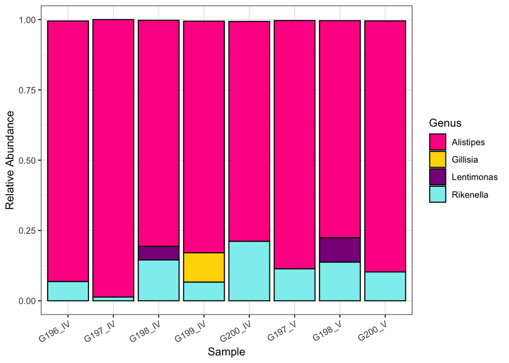

```r
Genus_df <-
  scaled_rooted_physeq %>%
  # agglomerate at the phylum level
  tax_glom(taxrank = "Genus") %>%
  # Transform counts to relative abundance
  transform_sample_counts(function (x) {x/sum(x)}) %>%
  # Melt to a long format
  psmelt() %>%
  # Filter out phyla that are less than one percent - get rid of low abundant Phyla
  dplyr::filter(Abundance > 0.01)


Genus_df %>%
  # Warning: Its important to have one sample per x value,
  # Otherwise, it will take the sum between multiple samples
  ggplot(aes(x = factor(Sample.Name, level = level_order),
             y = Abundance, fill = Genus)) +
  #facet_grid(.~gut_section) +
  geom_bar(stat = "identity", color = "black") +
  scale_fill_manual(values = Genus_colors) +
  theme_bw() +
  theme(axis.text.x = element_text(angle = 30, hjust = 1, vjust = 1)) +
  labs(y ="Relative Abundance", x = "Sample")
```